# Impact of Weather Phenomena on Human Health and Economy

Shaun

February 1, 2017

## Synopsis

Weather phenomena can be devastating due to the direct impact through fatalities and injuries and secondary effects through the economic impact. Understanding the potential impact that certain weather events may cause may inform public policy to deliver adequate resources and actions during those events. For the purpose of this report, data from National Oceanic and Atmospheric Administration’s (NOAA) storm database, between the years 1950 and 2011, was analysed to determine which weather phenomena has the greatest impact to public health and causes the most damage from an economic viewpoint. From the results of this report, we conclude that the weather event with the greatest impact to public health, by a significant proportion, is tornados. Floods have had the greatest impact on the economy. It is approximately double the impact of hurricane/typhoons which is the next greatest contributor.

## Data Processing

For the purpose of processing the data, the following software was used:  
* R v3.3.2  
* RStudio v1.0.136

### Processing

The storm data was obtained from the following link https://d396qusza40orc.cloudfront.net/repdata%2Fdata%2FStormData.csv.bz2.

```r
setwd("C:/Repository/shaun/ReproducibilityAssignment2-master")

# Downloading data into a created directory if the directory does not exist.
if (!dir.exists("./data/")){
  dir.create("./data/")
  download.file("https://d396qusza40orc.cloudfront.net/repdata%2Fdata%2FStormData.csv.bz2", destfile = "./data/data.csv.bz2")
}
# Reading in the downloaded data
rawdata <- read.csv("./data/data.csv.bz2", header=TRUE)
```

Transformations were made to the ‘PROPDMG’ and ‘CROPDMG’ columns based on the values contain within the ‘PROPDMGEXP’ and ‘CROPDMGEXP’ columns respectively.  
This was in order to obtain the absolute magnitude of ‘PROPDMG’ and ‘CROPDMG’ for comparisons.

```r
#Substituting in absolute values for property damage
tempvar <- which(toupper(rawdata$PROPDMGEXP) == "K")
rawdata[tempvar, "PROPDMG"] <- rawdata[tempvar, "PROPDMG"] * 10^3

tempvar <- which(toupper(rawdata$PROPDMGEXP) == "M")
rawdata[tempvar, "PROPDMG"] <- rawdata[tempvar, "PROPDMG"] * 10^6

tempvar <- which(toupper(rawdata$PROPDMGEXP) == "B")
rawdata[tempvar, "PROPDMG"] <- rawdata[tempvar, "PROPDMG"] * 10^9

#Substituting in absolute values for crop damage
tempvar <- which(toupper(rawdata$CROPDMGEXP) == "K")
rawdata[tempvar, "CROPDMG"] <- rawdata[tempvar, "CROPDMG"] * 10^3

tempvar <- which(toupper(rawdata$CROPDMGEXP) == "M")
rawdata[tempvar, "CROPDMG"] <- rawdata[tempvar, "CROPDMG"] * 10^6

tempvar <- which(toupper(rawdata$CROPDMGEXP) == "B")
rawdata[tempvar, "CROPDMG"] <- rawdata[tempvar, "CROPDMG"] * 10^9
```

According to the raw dataset, there are 985 unique storm event categories. However, this is as a result of inconsistent naming conventions in comparison to the 48 categories identified in Table 2.1.1 ‘Storm Data Event Table’ on page 6 of the document: https://d396qusza40orc.cloudfront.net/repdata%2Fpeer2_doc%2Fpd01016005curr.pdf. For the purpose of this analysis, each category will still be treated separately.

The raw data has been grouped by the storm event type ‘EVTYPE’ and their values summed up by the categories:  
* fatalities  
* injuries  
* property damage  
* crop damage

The total of property and crop damage have been scaled into billions of dollars to visually represent the discrepancy between the storm events.

```r
suppressMessages(library(dplyr))

#Summarise the data by storm type
eventsummary <- rawdata %>% group_by(EVTYPE) %>%
  summarise(fatalities= sum(FATALITIES), injuries = sum(INJURIES), propdmg = sum(PROPDMG), cropdmg = sum(CROPDMG))

#Create additional columns that aggregates fatalities with injuries and property damage with crop damage
eventsummary$humanimpact <- eventsummary$fatalities + eventsummary$injuries
eventsummary$economicimpact <- (eventsummary$propdmg + eventsummary$cropdmg)/10^9

#Create new variable based on the decending ordered set of economic data (property and crop damage)
ordered.economic <- eventsummary[order(eventsummary$economicimpact, decreasing = TRUE),]
ordered.economic$EVTYPE <- factor(ordered.economic$EVTYPE, levels = ordered.economic$EVTYPE[order(ordered.economic$economicimpact, decreasing = TRUE)])

#Create new variable based on the decending ordered set on human impact data (fatalities and injuries)
ordered.humanimpact <- eventsummary[order(eventsummary$humanimpact, decreasing = TRUE),]
ordered.humanimpact$EVTYPE <- factor(ordered.humanimpact$EVTYPE, levels = ordered.humanimpact$EVTYPE[order(ordered.humanimpact$humanimpact, decreasing = TRUE)])
```

## Results

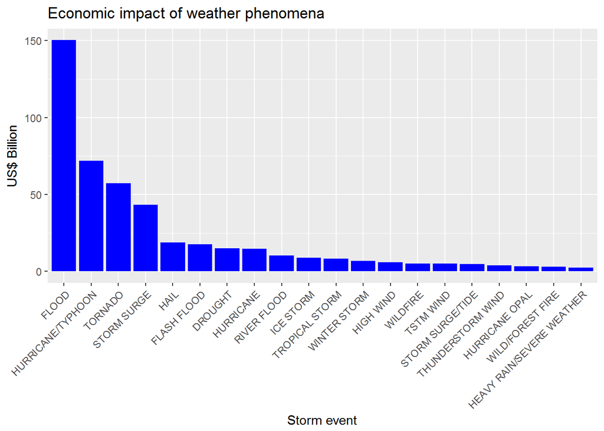

```r
suppressMessages(library(ggplot2))

ggplot(data = ordered.economic[1:20,], aes(EVTYPE))+
  geom_bar(aes(x = EVTYPE, y = economicimpact), stat = "identity", fill="blue")+
  ggtitle("Economic impact of weather phenomena")+
  ylab("US$ Billion")+
  xlab("Storm event")+
    theme( axis.text.x = element_text(angle=45, hjust=1))
```

As we can see from the graph above, the weather phenomena with the greatest impact to the economy, as determined by property and crop damage, is floods. This is followed by hurricanes/typhoons.

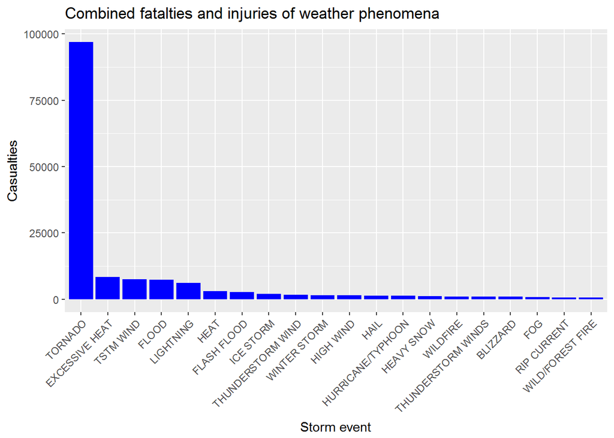

```r
ggplot(data = ordered.humanimpact[1:20,], aes(EVTYPE))+
  geom_bar(aes(x = EVTYPE, y = humanimpact), stat = "identity", fill="blue")+
  ggtitle("Combined fatalties and injuries of weather phenomena")+
  ylab("Casualties")+
  xlab("Storm event")+
    theme( axis.text.x = element_text(angle=45, hjust=1))
```

The graph above represents the number of human casualties sustained by weather phenomena. Tornados have the greatest impact to human wellbeing, by a significant margin, as determined by the number of fatalities and injuries sustained during tornado events.